# HW 1 Introduction

## EX1

- To get full marks in the homework exercises we have to use the right format. I will be using Jupyter Notebook which can be exported to a PDF file as a report and the Jupyter notebook file as the code. The homework should be submitted at time and answer all the questions. Failing to explain how I got my results or having unconvincing results can lead to grades deduction. In simple words, we have to convincing answers in the right format and submit the homework on time.
- "I will not plagiarize."
- "I understand and will follow the submission rules."

## EX2

Importing modules

```python
import sys
import random
import time
import matplotlib.pyplot as plt
import numpy as np

%matplotlib notebook
```

### Max value

- In python, the maximum size of an ‘int’ variable is defined according to the system. The max size is usually 2^30 on a 32-bit platform and 2^(62 )on a 64-bit platform according to python 3.7 documentation. I will call this value Max for the rest of the report.
- Maximum intger value (2^31 - 1 on a 32-bit machine and 2^63 - 1 on a 64-bit one)

```python
maxnum = sys.maxsize
```

### Random List Generator

A function to generate **N random numbers** between minN and maxN. The default value for minN is zero, and for maxN is maximum. Python random library by default uses a random seed so it generates different output for each function call and it uses a uniform selection. The function returns a list of N random intger numbers.

```python
def get_randN(N, minN=0, maxN=maxnum):
    Nnums = []
    for i in range(N):
        Nnums.append(random.randint(minN, maxN))
    return Nnums
```

### Sorting Algorithm

I implemented a **bubble sort function**, which takes a list of integers as input and outputs a new sorted list. Bubble sort algorithm works by simply swap any wrong ordered adjacent elements. It is a very simple sorting algorithm, but has a worst complexity and average complexity of n^2.

The following function is a simple implementation for bubble sort algorithm. It takes a list of integers as input and returns a new list with the integer numbers sorted.

```python
def bubble_sort(n_list):
    sorted_list = list(n_list)
    n = len(n_list)
    for i in range(n):
        for j in range(0, n-i-1):
            if sorted_list[j] > sorted_list[j+1]:
                sorted_list[j], sorted_list[j +1] = sorted_list[j+1], sorted_list[j]
    return sorted_list
```

### Experiments Generator

The following function is constructed to make it easy to run different experiments. In the function we can set the N, minN, maxN for the random range. The function allows the **repetition** of certain combination by using flag “rep”. Another flag is **“unique”** which controls whether the model will use different list of random integer numbers for each run during the repetition of the soring or not.

I record mean and standard deviation for the list of processing time for each experiment done, so I could compare between them.

```python
def sort_b(N, minN=0, maxN=maxnum, rep=1, unique=True):
    times = []
    Nnums = get_randN(N, minN, maxN)
    for i in range(rep):
        if unique:
            Nnums = get_randN(N, minN, maxN)
        t1=time.time()
        sorted_list = bubble_sort(Nnums)
        t2=time.time()
        times.append(float(t2-t1))
    return times,np.mean(times),np.std(times)
```

### Experiments

First we experiment with running the same list of 100 random numbers between 0,100. I will run the sorting code with this exact list for 20 times. I will record the mean and the standard deviation for the list of processing time for each run. We call this T1

```python
out=sort_b(N=100,minN=0,maxN=99,rep=20,unique=False)
```

Now we look at the mean and the standard deviation for T1

```python
print("T1 mean:%f sd:%f"%out[1:])
```

```
T1 mean:0.001351 sd:0.000474
```

- Now we test again 100 integer numbers, with minN and maxN as 0,and 99. But this time with unique set of integers for every run in the 20 repetitions. we call it T2.

```python
out=sort_b(N=100,minN=0,maxN=99,rep=20,unique=True)
print("T2 mean:%f sd:%f"%out[1:])
```

```
T2 mean:0.001352 sd:0.000475
```

test again integer 100 numbers , with minN and maxN as 0,and maxnum with unique set of integers for every run in the 20 repetitions. we call it T3.

```python
out=sort_b(N=100,minN=0,maxN=maxnum,rep=20,unique=True)
print("T3 mean:%f sd:%f"%out[1:])
```

```
T3 mean:0.001352 sd:0.000576
```

Changing maxN from 100 to **maxnum** hadn't affect the results much which is still same or closer to sorting with maximum value is 100.

- Next we try the same three experiments but with N set to 1000

```python
out=sort_b(N=1000,minN=0,maxN=1000,rep=20,unique=False)
print("T4 mean:%f sd:%f"%out[1:])
```

```
T4 mean:0.110259 sd:0.008639
```

```python
out=sort_b(N=1000,minN=0,maxN=1000,rep=20,unique=True)
print("T5 mean:%f sd:%f"%out[1:])
```

```
T5 mean:0.110798 sd:0.003288
```

```python
out=sort_b(N=1000,minN=0,maxN=maxnum,rep=2,unique=True)
print("T6 mean:%f sd:%f"%out[1:])
```

```
T6 mean:0.114400 sd:0.010271
```

The three values are similar, but the one where the range goes up to maxnum has some increase in the time average. comparing N=100 to N=1000 we see that N=1000 has much higher time average.

- we run two new tests with increasing the N to 10000, with one time max number is 10000 and another it is maxnum

```python
out=sort_b(N=10000,minN=0,maxN=10000,rep=1,unique=True)
print("T7 mean:%f sd:%f"%out[1:])
```

```
T7 mean:11.860209 sd:0.000000
```

```python
out=sort_b(N=10000,minN=0,maxN=maxnum,rep=1,unique=True)
print("T8 mean:%f sd:%f"%out[1:])
```

```
T8 mean:11.535510 sd:0.000000
```

From these results we can conclude that the increase in the size of the list "N" is not linearly linearly proportional to the increase in time average of the sorting process.

- Now we use a range to generate different lists with different sizes ranging from 10 to 10000 (with a step of 100) and max number is maxnum

```python
Ns=range(10,10000,100)
```

run the bubble sorting funciton

```python
y=[sort_b(N=N,minN=0,maxN=maxnum,rep=1,unique=True)[1] for N in Ns]
```

We know that bubble sort is of complexity $n^2$ but to overlay a more accurate function we have to get a constant values such that $$T(n)=Cn^2+k$$

Using values for N=1000 and N= 10000 we get $$T(1000)=c1000^+k=0.11 \, (eq.1) $$ and $$T(10000)=c1000^2+k=11.53\,(eq.2)$$

Subtracting eq.1 from eq.2 $$c10000^2-c1000^2=11.42$$ then $$c=1.1535353*10^-7$$ and $$k=11.53-10000^2*(1.15*10^-7)=-0.005$$

```python
yx2= [(N*N)/8695652.173 -.005 for N in Ns] #1/1.15*10^-7=8695652.173
```

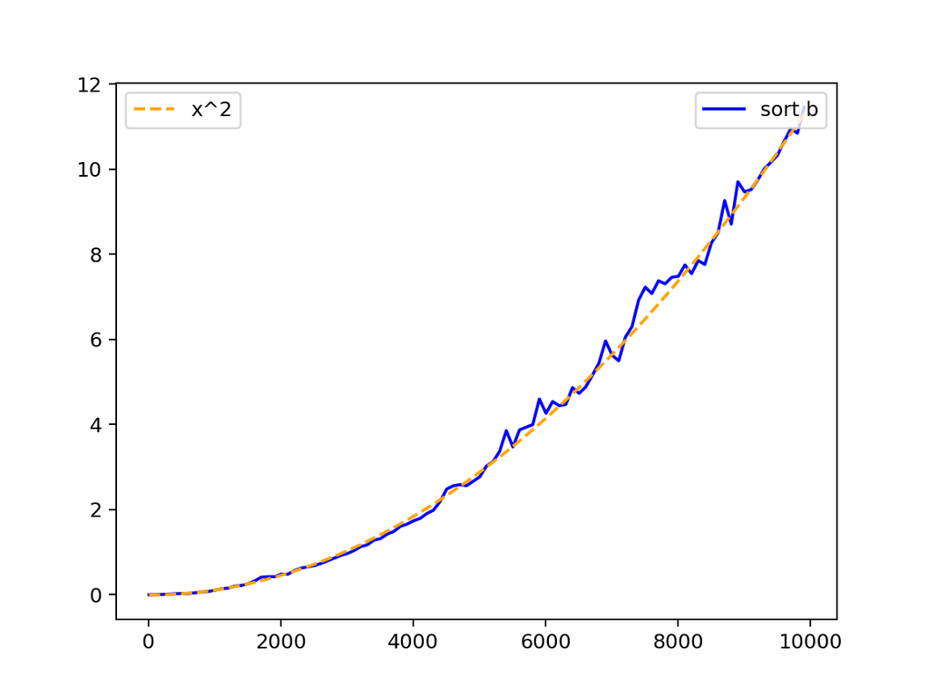

```python
#plt.plot(Ns, y)

line1, = plt.plot(Ns,y, label="sort b", linestyle='-',color='blue')
line2, = plt.plot(Ns,yx2, label="x^2", linestyle='--',color='orange')

# Create a legend for the first line.
first_legend = plt.legend(handles=[line1], loc=1)

# Add the legend manually to the current Axes.
ax = plt.gca().add_artist(first_legend)

# Create another legend for the second line.
plt.legend(handles=[line2],loc=0)

plt.show()
```

- The dashed curve is the normalized x^2 function and the blue curve is for the bubble sort. The blue curve is not a smooth one and it is not perfect x^2 curve due to the fact that average time changes for each random list used. as we saw for the same range and same size of lists time varies, as the values changes and the order changes.
- Another reason that the blue curve is not smooth is that the fact that not all experiments are run in the exact same conditions since that many programs are running while I'm doing the experiments on my machine which is something hard to control (hardware).

## EX3

- Python has a built in function that is called "sort()", which sort a list wihtout creating a new one (which saves time). It has a worst case complexity of O(nlogn) which is much faster than bubble sort used in EX2. The algorthim used is called Timsort (https://en.wikipedia.org/wiki/Timsort)

### Experiments Generator

The following is a function that utilizes python 'sort' function to run sorting experiments and recode time. Similar to EX2.

```python
def sort_py(N, minN=0, maxN=maxnum, rep=1, unique=True):
    times = []
    Nnums = get_randN(N, minN, maxN)
    for i in range(rep):
        if unique:
            Nnums = get_randN(N, minN, maxN)
        t1=time.time()
        sorted_list = Nnums.sort()
        t2=time.time()
        times.append(float(t2-t1))
    return times,np.mean(times),np.std(times)
```

Running similar experiments on the python built-in sorting function, where the sizes are 1000,10000,and 100000.

```python
out=sort_py(N=1000,minN=0,maxN=1000,rep=20,unique=True)
print("T9 mean:%f sd:%f"%out[1:])
```

```
T9 mean:0.000250 sd:0.000433
```

```python
out=sort_py(N=1000,minN=0,maxN=maxnum,rep=20,unique=True)
print("T10 mean:%f sd:%f"%out[1:])
```

```
T10 mean:0.000299 sd:0.000457
```

This time the change in the maximum number increases the time average of the sorting process.

```python
out=sort_py(N=10000,minN=0,maxN=10000,rep=20,unique=True)
print("T11 mean:%f sd:%f"%out[1:])
```

```
T11 mean:0.002964 sd:0.004476
```

```python
out=sort_py(N=10000,minN=0,maxN=maxnum,rep=20,unique=True)
print("T12 mean:%f sd:%f"%out[1:])
```

```
T12 mean:0.003717 sd:0.005257
```

last set of experiments by inceasing the list size to 100000

```python
out=sort_py(N=100000,minN=0,maxN=100000,rep=20,unique=True)
print("T13 mean:%f sd:%f"%out[1:])
```

```
T13 mean:0.040544 sd:0.005983
```

```python
out=sort_py(N=100000,minN=0,maxN=maxnum,rep=20,unique=True)
print("T14 mean:%f sd:%f"%out[1:])
```

```
T14 mean:0.046144 sd:0.003567
```

The main difference between bubble sort, and python sort function is that the time average numbers grow in much less pace in the case of python sort. Python sort is also affected by the maximum value in the list.

- The final experiment is similar to the one used to plot the graph in Ex2.

```python
y1=[sort_py(N=N,minN=0,maxN=maxnum,rep=100,unique=True)[1] for N in Ns]
```

We know that python sort function has complexity of nlogn we do the same as EX2 to get the c and k

$$T(n)=Cn\log_{10}n+k$$

```python
y2 = [(N*np.log10(N))/12503407.18 -0.0005 for N in Ns]
```

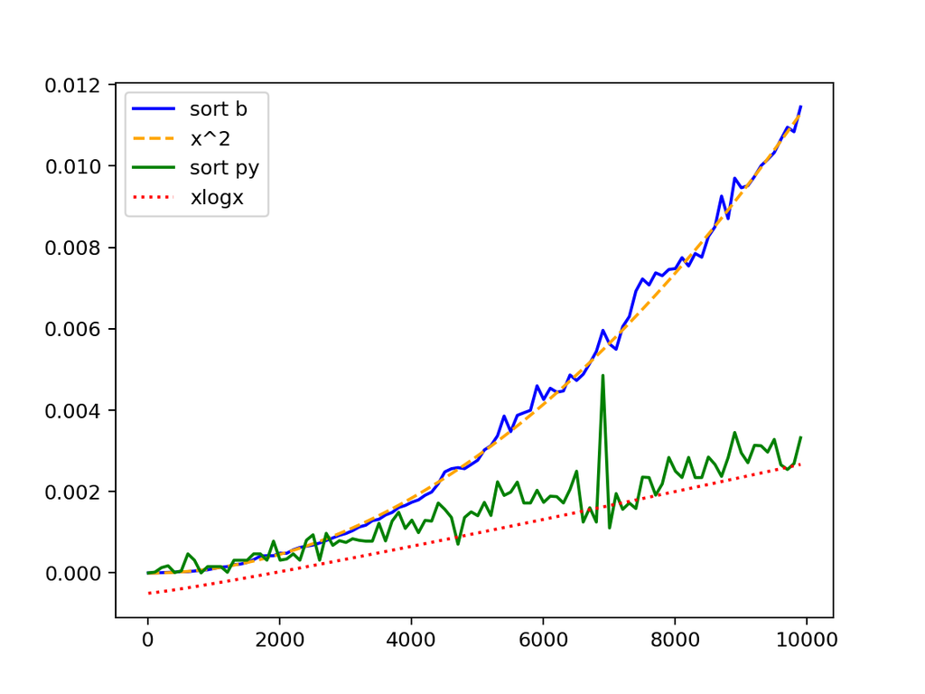

```python
line1, = plt.plot(Ns,[i * 0.001 for i in y], label="sort b", linestyle='-',color='blue')
line2, = plt.plot(Ns,[i * 0.001 for i in yx2], label="x^2", linestyle='--',color='orange')

line3, = plt.plot(Ns,y1, label="sort py", linestyle='-',color='green')
line4, = plt.plot(Ns,y2, label="xlogx", linestyle=':',color="red")

# Create a legend for the first line.
#first_legend = plt.legend(handles=[line1], loc=1)

# Add the legend manually to the current Axes.
#ax = plt.gca().add_artist(first_legend)

# Create another legend for the second line.
plt.legend(loc=0)

plt.show()
```

The plot shows how fast the complexity of bubble sort grows comparing to python sort. Showing that python sort is much faster than bubble sort.

- The **functions** , I used in the graph was mainly used due to my knowledge of the complexity of each algorithms and I used some constants to normalize the values so it in one graph and so we could easily compare them.

## EX4

In this exercise, I have to find the size of the list sorted in one minute for each algorithm. I started with values expected to take 1 min, by using the results from previous tests, then did extra experiments to get the exact values.

- **one important note** is that the time will not be exact all the time since value of the list change (they are random), and it will change when tested on different machines too.

#### - 1 min bubble sort

```python
out=sort_b(N=23000,minN=0,maxN=maxnum,rep=1,unique=True)
print("Tmin_b mean:%f sd:%f"%out[1:])
```

```
Tmin_b mean:63.549421 sd:0.000000
```

I will try and validate this number by checking the function i used in the plot in EX2

$$T(n)=n^2*1.1535353*10^-7-0.005=23000^2*1.1535353*10^-7-0.005=61.01\,seconds $$

The answer if very close (it might change every run) which means the function can be used to extrapolate results

#### - 1 min python sort

```python
out=sort_py(N=50000000,minN=0,maxN=maxnum,rep=1,unique=True)
print("Tmin_py mean:%f sd:%f"%out[1:])
```

```
Tmin_py mean:75.199472 sd:0.000000
```

If we do the same validation step as bubble sort:

$$T(n)=\frac{n\log_{10} n}{12503407.18}-0.0005=\frac{50000000*\log_{10} 50000000}{12503407.18}-0.0005=30.76 seconds $$

Using the function we got a value less than a minute, the issue comes from the fact when using python sort function we deal with very large lists and more probability to have larger numbers, which adds complications to the machine apart from the algorithm complexity.

#### - For 100 times means running **bubble sort** for N = 2300000

$$T(n)=n^2*1.1535353*10^-7-0.005=2300000^2*1.1535353*10^-7-0.005=610220.16\,seconds=7.06\, days $$

#### - For 100 times means running **python sort** for N = 5000000000

$$T(n)=\frac{n\log_10 n}{15000000}=\frac{5000000000*\log_10 5000000000}{12503407.18}-0.0005=3878.525\, seconds = 64.64\, minutes $$

The graphs and functions are in Ex2 and EX3.

## EX5

$f(n) = 8n^3 + n$

$g(n) = n^3$

Using Asymptotic Analysis

$$\lim_{n \to \infty} \frac {f(n)}{ g(n)} = \lim_{x \to \infty} \frac {8n^3 + n}{ n^3}= \lim_{x \to \infty} \frac {8n^2 + 1}{ n^2} = \frac{8}{1}=8 $$

$$0< \frac {f(n)}{ g(n)}<\infty$$

since the limit is constant then this proves that $$f(n)= \theta(g(n))$$

which menas $$ c_1g(n) \leq f(n) \leq c_2g(n) $$ for all $$ n>n_0 $$

$$ c_1 n^3 \leq 8n^3+n \leq c_2 n^3 $$

dividing by n^3 $$ c_1 \leq 8+\frac{1}{n} \leq c_2 $$

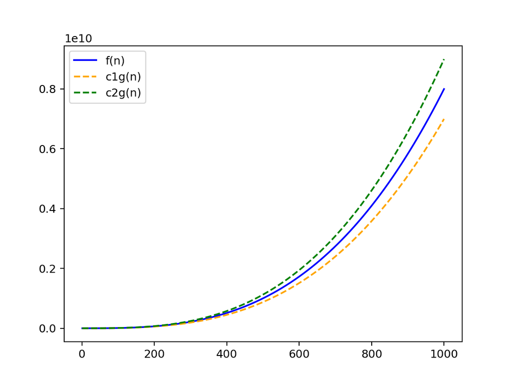

```python
x= list(np.arange(1,1000,0.1))
line1, = plt.plot(x,[8*(i*i*i) + i for i in x], label="f(n)", linestyle='-',color='blue')
line2, = plt.plot(x,[7 *(i*i*i) for i in x], label="c1g(n)", linestyle='--',color='orange')
line3, = plt.plot(x,[9 *(i*i*i) for i in x], label="c2g(n)", linestyle='--',color='green')

plt.legend(loc=0)

plt.show()
```

The graph is a representation of $\theta$ notation.

## EX 6

- First I created a function similar to shuffle in python which randomize a python list. using " Fisher–Yates shuffling" https://en.wikipedia.org/wiki/Fisher%E2%80%93Yates_shuffle

```python
def shuffle_list(n_list):
    shuffled_list = list(n_list)
    n = len(n_list)
    for i in range(n):
        j  = random.randint(0,(n-1-i))
        shuffled_list[j], shuffled_list[n-1-i] = shuffled_list[n-1-i], shuffled_list[j]
    return shuffled_list
```

- then created a function that checks if a list is sorted by checking if every element is less than the next element if not then it is not sorted

```python
def is_sorted(n_list):
    for i in range(len(n_list)-1):
        if n_list[i]>n_list[i+1]:
            return False
    return True
```

- The sorting function simply takes a list as input and keeps shuffling the list (creating permutations) until the list is sorted then it returns the sorted list

```python
def random_sort(n_list):
    while True:
        new_list=shuffle_list(n_list)
        if is_sorted(new_list):
            return new_list
```

- we could say that such function has an average of O(n!), but since some permutations can be repeated it can grow much higher than this maybe go infinitely complex

The following function is to create experiments using the random sort function.

```python
def sort_random(N, minN=0, maxN=maxnum, rep=1, unique=True):
    times = []
    Nnums = get_randN(N, minN, maxN)
    for i in range(rep):
        if unique:
            Nnums = get_randN(N, minN, maxN)
        t1=time.time()
        sorted_list = random_sort(Nnums)
        t2=time.time()
        times.append(float(t2-t1))
    return times,np.mean(times),np.std(times)
```

```python
sort_random(2)
```

```
([0.0], 0.0, 0.0)
```

```python
sort_random(3)
```

```
([0.0005002021789550781], 0.0005002021789550781, 0.0)
```

```python
sort_random(6)
```

```
([0.005001544952392578], 0.005001544952392578, 0.0)
```

```python
sort_random(8)
```

```
([0.10907578468322754], 0.10907578468322754, 0.0)
```

```python
sort_random(9)
```

```
([10.099539518356323], 10.099539518356323, 0.0)
```

```python
sort_random(10)
```

```
([53.712024211883545], 53.712024211883545, 0.0)
```

```python
sort_random(11)
```

```
([504.7394754886627], 504.7394754886627, 0.0)
```

The main problem with such algorithm is that it is very fast growing in complexity. It is not even comparable to bubble sort which has complexity of $n^2$. From the previous results Assuming that the algorithm has a complexity of $$T(n)=cn!+k$$ And we know $$T(9)=c9!+k=10$$ And $$T(10)=c10!+k=53$$ Then $$c10!-c9!=43$$ So $$c=1.316627474*10^-5$$ And $$k=5.2222222$$ Getting T(11) $$T(11)=1.3166274*10^-5*11!+5.222222=530.777$$ Which is **close to the actual output**

Using this function to get $ T(30)$ $$T(30)= 1.3166274*10^-5*30!+5.222222=3.49*10^{27}\, seconds $$ Which is much more than a lifetime.